# Credit card Fraud Detection and investigation of various Data Imputation techniques

## Overview

In this project we will be following the workflow for a machine learning project as defined in [O'Reilly's Hands-on Machine Learning](https://www.oreilly.com/library/view/hands-on-machine-learning/9781492032632/) textbook:

1. Frame the problem
2. Get the data
3. Explore the data
4. Prepare the data
5. Explore models
6. Fine-tune models
7. Present solution

## 1. Frame the problem

The goal of this project is to use a binary classifier to identify fraudulent transactions. The training data comes from a [Kaggle competition](https://www.kaggle.com/competitions/playground-series-s3e4/) that contains partially generated and partially real data.

For this project, we will be using ROC-AUC as our performance metric. ROC-AUC is a metric used specifically for binary classification models, and works by plotting an ROC curve, which is the True Positive rate against the False Positive rate at different thresholds, and then calculates the area under this curve. A perfect ROC-AUC score is therefore 1, and completely random (with balanced classes) would be 0.5 (higher is better). The reasons behind choosing this metric are:

- ROC-AUC is insensitive to class balance, which is crucial for our data given that we have very few instances of fraudulent transactions
- It provides a single number which makes it easy to compare model performance
- Kaggle uses this performance metric, so it is easy to see how our preliminary models compare to other submissions

Although there is no missing data present in the training set, we will manually introduce them so we can investigate various Data Imputation methods.

## 2. Get the data

Import the data, as well as the relevant libraries to be used.

```python
import sys
!{sys.executable} -m pip install numpy pandas matplotlib scikit-learn seaborn statsmodels imblearn xgboost | grep -v 'already satisfied'

import pandas as pd
import numpy
import numpy as np
import matplotlib.pyplot

# Read the training dataset from a file on studres.
train = pd.read_csv("/train.csv")
test = pd.read_csv("/test.csv")
# Clear the maximum number of columns to be displayed, so that all will be visible.
pd.set_option('display.max_columns', None)
```

[output not shown]

## 3. Explore the data

To start with lets explore the structure of the data

```python
train.head()
```

|  | id | Time | V1 | V2 | V3 | V4 | V5 | V6 | V7 | V8 | V9 | V10 | V11 | V12 | V13 | V14 | V15 | V16 | V17 | V18 | V19 | V20 | V21 | V22 | V23 | V24 | V25 | V26 | V27 | … |
| --- | --- | --- | --- | --- | --- | --- | --- | --- | --- | --- | --- | --- | --- | --- | --- | --- | --- | --- | --- | --- | --- | --- | --- | --- | --- | --- | --- | --- | --- | --- |
| 0 | 0 | 0.0 | 2.074329 | -0.129425 | -1.137418 | 0.412846 | -0.192638 | -1.210144 | 0.110697 | -0.263477 | 0.742144 | 0.108782 | -1.070243 | -0.234910 | -1.099360 | 0.502467 | 0.169318 | 0.065688 | -0.306957 | -0.323800 | 0.103348 | -0.292969 | -0.334701 | -0.887840 | 0.336701 | -0.110835 | -0.291459 | 0.207733 | -0.076576 | … |
| 1 | 1 | 0.0 | 1.998827 | -1.250891 | -0.520969 | -0.894539 | -1.122528 | -0.270866 | -1.029289 | 0.050198 | -0.109948 | 0.908773 | 0.836798 | -0.056580 | -0.120990 | -0.144028 | -0.039582 | 1.653057 | -0.253599 | -0.814354 | 0.716784 | 0.065717 | 0.054848 | -0.038367 | 0.133518 | -0.461928 | -0.465491 | -0.464655 | -0.009413 | … |
| 2 | 2 | 0.0 | 0.091535 | 1.004517 | -0.223445 | -0.435249 | 0.667548 | -0.988351 | 0.948146 | -0.084789 | -0.042027 | -0.818383 | -0.376512 | -0.226546 | -0.552869 | -0.886466 | -0.180890 | 0.230286 | 0.590579 | -0.321590 | -0.433959 | -0.021375 | -0.326725 | -0.803736 | 0.154495 | 0.951233 | -0.506919 | 0.085046 | 0.224458 | … |
| 3 | 3 | 0.0 | 1.979649 | -0.184949 | -1.064206 | 0.120125 | -0.215238 | -0.648829 | -0.087826 | -0.035367 | 0.885838 | -0.007527 | 0.637441 | 0.676960 | -1.504823 | 0.554039 | -0.824356 | -0.527267 | -0.095838 | -0.312519 | 0.642659 | -0.340089 | -0.095514 | -0.079792 | 0.167701 | -0.042939 | 0.000799 | -0.096148 | -0.057780 | … |
| 4 | 4 | 0.0 | 1.025898 | -0.171827 | 1.203717 | 1.243900 | -0.636572 | 1.099074 | -0.938651 | 0.569239 | 0.692665 | -0.097495 | 1.338869 | 1.391399 | -0.128167 | -0.081836 | 0.100548 | -0.338937 | 0.090864 | -0.423645 | -0.731939 | -0.203628 | 0.099157 | 0.608908 | 0.027901 | -0.262813 | 0.257834 | -0.252829 | 0.108338 | … |

We notice a few things. Most of the features are given generic names, so this doesn't give us any intuitive understanding of whether they may or may not be important for use to include in models. Some of the features are named, however, and contain more specific information about the transaction represented by each row. From Kaggle:

- `Time` contains the seconds elapsed between each transaction and the first transaction in the dataset.
- `Amount` is the transaction Amount
- `Class` is the response variable and it takes value 1 in case of fraud and 0 otherwise.

We also learn from Kaggle that features V1, V2, … V28 are the principal components obtained with PCA, meaning that we may not need to do any dimensionality reduction on this data.

We can begin exporation of the datasets by inspecting the statistics of each column.

```python
train.describe()
```

|  | id | Time | V1 | V2 | V3 | V4 | V5 | V6 | V7 | V8 | V9 | V10 | V11 | V12 | V13 | V14 | V15 | V16 | V17 | V18 | V19 | V20 | V21 | V22 | V23 | V24 | V25 | V26 | V27 | … |
| --- | --- | --- | --- | --- | --- | --- | --- | --- | --- | --- | --- | --- | --- | --- | --- | --- | --- | --- | --- | --- | --- | --- | --- | --- | --- | --- | --- | --- | --- | --- |
| count | 219129.000000 | 219129.000000 | 219129.000000 | 219129.000000 | 219129.000000 | 219129.000000 | 219129.000000 | 219129.000000 | 219129.000000 | 219129.000000 | 219129.000000 | 219129.000000 | 219129.000000 | 219129.000000 | 219129.000000 | 219129.000000 | 219129.000000 | 219129.000000 | 219129.000000 | 219129.000000 | 219129.000000 | 219129.000000 | 219129.000000 | 219129.000000 | 219129.000000 | 219129.000000 | 219129.000000 | 219129.000000 | 219129.000000 | … |
| mean | 109564.000000 | 62377.415376 | 0.096008 | 0.048345 | 0.592102 | 0.069273 | -0.161555 | 0.133688 | -0.128224 | 0.149534 | -0.048337 | -0.039758 | 0.153632 | -0.061038 | 0.014330 | 0.067649 | 0.108643 | 0.013650 | 0.036815 | -0.033927 | -0.008302 | 0.009708 | -0.031064 | -0.050852 | -0.050531 | -0.002992 | 0.124005 | 0.009881 | 0.014034 | … |
| std | 63257.237906 | 25620.348569 | 1.395425 | 1.159805 | 1.132884 | 1.253125 | 1.069530 | 1.202411 | 0.817207 | 0.716212 | 1.054143 | 0.821889 | 0.976946 | 0.998470 | 1.039145 | 0.801335 | 0.891613 | 0.786654 | 0.691709 | 0.784454 | 0.739928 | 0.439521 | 0.422777 | 0.597812 | 0.318175 | 0.593100 | 0.406741 | 0.473867 | 0.233355 | … |
| min | 0.000000 | 0.000000 | -29.807725 | -44.247914 | -19.722872 | -5.263650 | -37.591259 | -25.659750 | -31.179799 | -28.903442 | -8.756951 | -22.092656 | -4.190145 | -16.180165 | -4.373778 | -15.585021 | -4.155728 | -11.778839 | -20.756768 | -7.456060 | -4.281628 | -18.679066 | -14.689621 | -8.748979 | -11.958588 | -2.836285 | -3.958591 | -1.858672 | -9.234767 | … |
| 25% | 54782.000000 | 47933.000000 | -0.846135 | -0.573728 | -0.027154 | -0.769256 | -0.847346 | -0.631835 | -0.646730 | -0.095948 | -0.711444 | -0.499563 | -0.576969 | -0.476890 | -0.671601 | -0.329905 | -0.461596 | -0.461077 | -0.406675 | -0.496990 | -0.463035 | -0.167927 | -0.190418 | -0.473099 | -0.174478 | -0.332540 | -0.126080 | -0.318330 | -0.050983 | … |
| 50% | 109564.000000 | 63189.000000 | 0.385913 | 0.046937 | 0.735895 | 0.064856 | -0.229929 | -0.087778 | -0.098970 | 0.111219 | -0.131323 | -0.106034 | 0.090545 | 0.087649 | -0.016837 | 0.049266 | 0.178975 | 0.054550 | -0.013949 | -0.039451 | -0.002935 | -0.037702 | -0.042858 | -0.032856 | -0.063307 | 0.038708 | 0.145934 | -0.086388 | 0.015905 | … |
| 75% | 164346.000000 | 77519.000000 | 1.190661 | 0.814145 | 1.306110 | 0.919353 | 0.356856 | 0.482388 | 0.385567 | 0.390976 | 0.583715 | 0.403967 | 0.917392 | 0.608480 | 0.695547 | 0.460837 | 0.791255 | 0.531777 | 0.410978 | 0.446448 | 0.455718 | 0.126750 | 0.109187 | 0.354910 | 0.060221 | 0.394566 | 0.402926 | 0.253869 | 0.076814 | … |
| max | 219128.000000 | 120580.000000 | 2.430494 | 16.068473 | 6.145578 | 12.547997 | 34.581260 | 16.233967 | 39.824099 | 18.270586 | 13.423914 | 15.878405 | 9.417789 | 5.406614 | 5.976265 | 6.078453 | 4.693323 | 5.834992 | 8.845303 | 4.847887 | 4.090974 | 15.407839 | 22.062945 | 6.163541 | 12.734391 | 4.572739 | 3.111624 | 3.402344 | 13.123618 | … |

We can then plot histograms of each of the features, to get an understanding of the spread and range of values for each of the features.

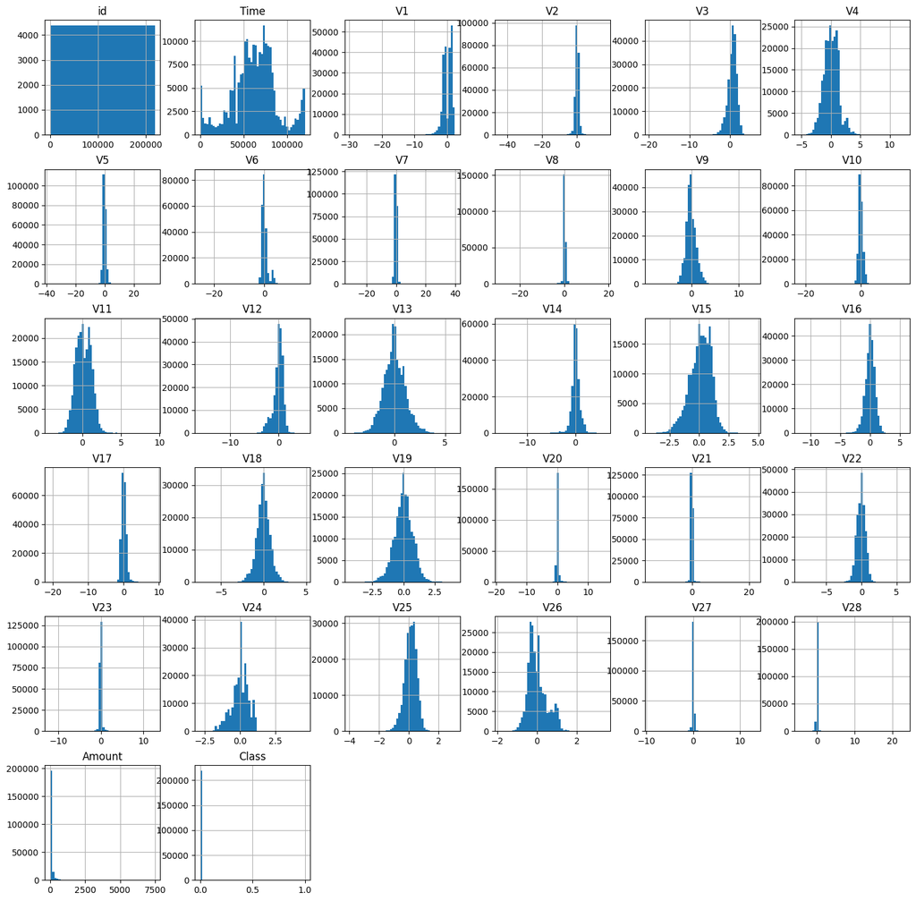

```python
train.hist(bins=50,
          figsize=(18,18))
matplotlib.pyplot.show()
```

By combining the histograms with the `.describe()` info, we can see that the variables `V1, ..., V28` have been normalized. We can tell this is the case as the standard deviation for these variables is around 1 and the mean is around zero. We also see that many of the columns have outliers, which we can deal with in the data cleaning stage. We can also plot a the correlations of each attributes with the `Class` response variable to get an initial understanding of which variables may be the most important.

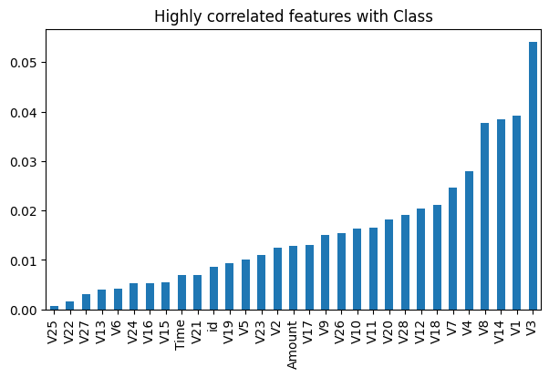

```python
#looking at correlation of the attributes to price

from matplotlib import pyplot as plt
plt.figure(figsize=(7,4))
fig_data = train.corr()['Class'][:-1].abs().sort_values().plot(kind='bar', title='Highly correlated features with Class')
```

The correlations of the individual variables with the response are all very low, so we can't initially identify which may be the most important. We can also plot correlation matrix to see which variables may have strong correlation with each other. If we see any high correlations within the data, it may be worth removing these columns to reduce column collinearity.

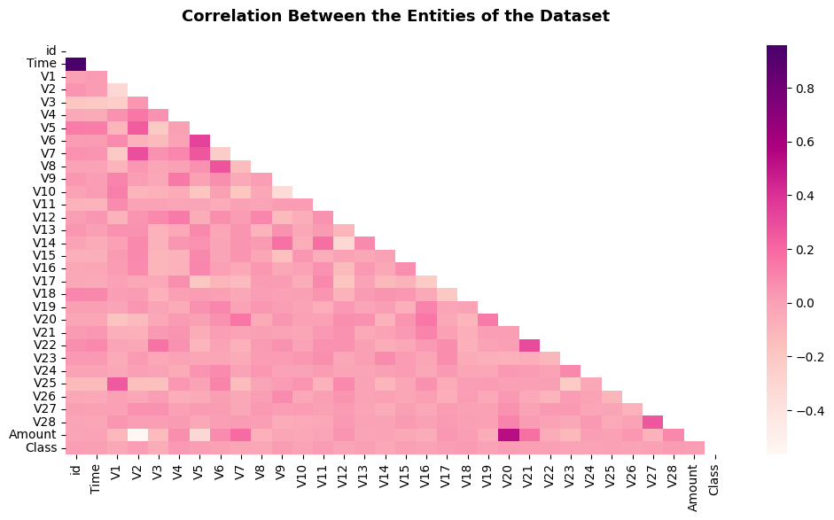

```python
import numpy as np
import matplotlib
import seaborn as sns
correlation = train.corr()
mask = np.triu(np.ones_like(correlation))

plt.figure(figsize=(12, 6))

plt.title(
    'Correlation Between the Entities of the Dataset',
    fontweight='bold',
    fontsize=13,
    y=1.04
)


sns.heatmap(
    correlation,
    annot=False,
    cmap='RdPu',
    mask=mask,
)
```

From this plot, we can see that `Time` and `id` are very highly correlated. This is because `id` appears to represent the index of the data, and `Time` represents the time in seconds elapsed between each transaction and the first transaction in the dataset. They therefore represent very similar information, and we can reasonably drop `id` from our model training. We also see strong correlation between `Amount` and `V20`, although since we do not know the context/meaning of `V20`, it is impossible to think of a reason behind why this is the case.

## 4. Prepare the data

### Imputation

In this dataset, there are no missing values to be imputed, however we will extend this project by randomly removing values and investigating various data imputation methods

To start we take a copy of the data so we can remove values and impute without changing the dataframe we will use to train models.

```python
imp_train = train.copy()
imp_train.info()
```

```
<class 'pandas.core.frame.DataFrame'>
RangeIndex: 219129 entries, 0 to 219128
Data columns (total 32 columns):
 #   Column  Non-Null Count   Dtype
---  ------  --------------   -----
 0   id      219129 non-null  int64
 1   Time    219129 non-null  float64
 2   V1      219129 non-null  float64
 3   V2      219129 non-null  float64
 4   V3      219129 non-null  float64
 5   V4      219129 non-null  float64
 6   V5      219129 non-null  float64
 7   V6      219129 non-null  float64
 8   V7      219129 non-null  float64
 9   V8      219129 non-null  float64
```

[output cut: 24 more lines]

As we can see, all columns have no mising values

Remove the columns `id` and `Class`:

- `id` refers to the index of the row, so makes no sense for there to be missing values, therefore we have no reason to test imputation methods on this column
- `Class` is the response variable, so if there is missing data in this column, we would predict on this row instead of imputing the missing value

```python
imp_train.drop(inplace=True, columns= ['id' , 'Class'])
num_rows, num_cols = imp_train.shape
```

Before we impute lets keep a copy of the true values for the data, so we can evaluate our imputation methods later

```python
trueValues = imp_train.copy()
```

Remove a random selection of 10% of the data by randomly selecting row and column indices pairs, with each row and column having a 10% probability of being selected

```python
def removeVals (dataset, total_vals, percent_to_remove):
    dataset = dataset.copy()
    rows_to_remove = dataset.sample(frac = percent_to_remove, replace = True).index
    for i in rows_to_remove:
        column_to_remove = dataset.sample(n=1, axis=1).columns[0]
        dataset.loc[i, column_to_remove] = numpy.nan
    return dataset


imp_train = removeVals(imp_train, num_rows, 0.1*num_cols)
```

Lets check this worked

```python
imp_train.info()
```

```
<class 'pandas.core.frame.DataFrame'>
RangeIndex: 219129 entries, 0 to 219128
Data columns (total 30 columns):
 #   Column  Non-Null Count   Dtype
---  ------  --------------   -----
 0   Time    198513 non-null  float64
 1   V1      198134 non-null  float64
 2   V2      198219 non-null  float64
 3   V3      198340 non-null  float64
 4   V4      198467 non-null  float64
 5   V5      198450 non-null  float64
 6   V6      198134 non-null  float64
 7   V7      198283 non-null  float64
 8   V8      198250 non-null  float64
 9   V9      198073 non-null  float64
```

[output cut: 22 more lines]

We have removed some data, now we can check how much missing data in each column for another sanity check

```python
for column_name in imp_train.columns:
    num_missing = imp_train[column_name].isna().sum()
    print(f"{column_name}: {num_missing}")
```

```
Time: 20616
V1: 20995
V2: 20910
V3: 20789
V4: 20662
V5: 20679
V6: 20995
V7: 20846
V8: 20879
V9: 21056
V10: 20838
V11: 20899
V12: 21018
V13: 20845
V14: 20959
V15: 21130
V16: 20862
V17: 20655
V18: 20710
V19: 20934
V20: 20887
V21: 20775
V22: 20737
V23: 21008
V24: 20938
V25: 21041
V26: 20775
V27: 20792
V28: 20922
Amount: 20679
```

Looks correct by eye

Before we start imputing lets look at the data again

```python
imp_train.head()
```

|  | Time | V1 | V2 | V3 | V4 | V5 | V6 | V7 | V8 | V9 | V10 | V11 | V12 | V13 | V14 | V15 | V16 | V17 | V18 | V19 | V20 | V21 | V22 | V23 | V24 | V25 | V26 | V27 | V28 | … |
| --- | --- | --- | --- | --- | --- | --- | --- | --- | --- | --- | --- | --- | --- | --- | --- | --- | --- | --- | --- | --- | --- | --- | --- | --- | --- | --- | --- | --- | --- | --- |
| 0 | NaN | 2.074329 | -0.129425 | -1.137418 | 0.412846 | -0.192638 | -1.210144 | 0.110697 | -0.263477 | 0.742144 | 0.108782 | -1.070243 | -0.234910 | NaN | 0.502467 | NaN | 0.065688 | -0.306957 | -0.323800 | 0.103348 | -0.292969 | -0.334701 | -0.887840 | 0.336701 | -0.110835 | -0.291459 | 0.207733 | -0.076576 | -0.059577 | … |
| 1 | NaN | 1.998827 | -1.250891 | -0.520969 | -0.894539 | -1.122528 | -0.270866 | -1.029289 | 0.050198 | -0.109948 | 0.908773 | 0.836798 | -0.056580 | -0.120990 | -0.144028 | -0.039582 | 1.653057 | -0.253599 | -0.814354 | 0.716784 | NaN | 0.054848 | -0.038367 | 0.133518 | -0.461928 | -0.465491 | -0.464655 | -0.009413 | -0.038238 | … |
| 2 | 0.0 | 0.091535 | 1.004517 | -0.223445 | -0.435249 | 0.667548 | -0.988351 | NaN | -0.084789 | -0.042027 | -0.818383 | -0.376512 | -0.226546 | -0.552869 | -0.886466 | -0.180890 | NaN | 0.590579 | -0.321590 | -0.433959 | -0.021375 | -0.326725 | -0.803736 | 0.154495 | 0.951233 | -0.506919 | NaN | 0.224458 | 0.087356 | … |
| 3 | 0.0 | 1.979649 | -0.184949 | -1.064206 | 0.120125 | -0.215238 | -0.648829 | -0.087826 | -0.035367 | 0.885838 | -0.007527 | NaN | 0.676960 | NaN | 0.554039 | -0.824356 | -0.527267 | -0.095838 | -0.312519 | 0.642659 | NaN | -0.095514 | NaN | 0.167701 | -0.042939 | 0.000799 | -0.096148 | -0.057780 | -0.073839 | … |
| 4 | 0.0 | 1.025898 | -0.171827 | 1.203717 | 1.243900 | -0.636572 | 1.099074 | -0.938651 | NaN | 0.692665 | -0.097495 | 1.338869 | 1.391399 | -0.128167 | -0.081836 | NaN | NaN | 0.090864 | -0.423645 | -0.731939 | -0.203628 | 0.099157 | 0.608908 | 0.027901 | -0.262813 | 0.257834 | -0.252829 | 0.108338 | 0.021051 | … |

### Imputation Setup

Here we will make 4 copies of the data with missing values, one to use with each of the imputation methods.

```python
imp_train_1 = imp_train.copy()
imp_train_2 = imp_train.copy()
imp_train_3 = imp_train.copy()
imp_train_4 = imp_train.copy()
```

We can also create a mask of which values are missing and which values are not missing, so we can directly compare the imputed values with the original values.

```python
mask_missing_values =  imp_train.isna()
mask_missing_values.head()
```

|  | Time | V1 | V2 | V3 | V4 | V5 | V6 | V7 | V8 | V9 | V10 | V11 | V12 | V13 | V14 | V15 | V16 | V17 | V18 | V19 | V20 | V21 | V22 | V23 | V24 | V25 | V26 | V27 | V28 | … |
| --- | --- | --- | --- | --- | --- | --- | --- | --- | --- | --- | --- | --- | --- | --- | --- | --- | --- | --- | --- | --- | --- | --- | --- | --- | --- | --- | --- | --- | --- | --- |
| 0 | True | False | False | False | False | False | False | False | True | False | False | False | False | True | False | True | False | False | False | False | False | False | False | False | False | False | False | False | False | … |
| 1 | True | False | False | False | False | False | False | False | False | False | False | True | False | False | False | False | True | False | False | False | True | False | False | False | False | False | False | False | False | … |
| 2 | False | False | False | False | False | False | True | True | True | False | False | False | True | False | False | False | True | False | False | False | False | False | False | False | False | False | True | False | False | … |
| 3 | False | False | False | False | False | False | False | False | False | False | True | True | False | True | False | False | False | False | False | False | True | False | True | False | False | False | False | False | False | … |
| 4 | False | False | False | False | False | False | False | False | True | False | False | False | False | False | False | True | True | False | False | False | False | False | False | False | False | False | False | False | False | … |

#### Simple imputation

The first method uses SciKit Learn's `SimpleImputer`, and we will use `strategy = "median"`. This will replace the missing values with the median of the non-missing values in it's column. This will preserve the distribution of values as best as possible and is also one of the most common. Additionally, using the median rather than the mean is more robust to outliers. Finally, this method takes a trivial amount of time to run.

```python
from sklearn.impute import SimpleImputer

medianImputer = SimpleImputer(strategy = "median")
```

```python
# Get a list of the column names so we can re-label the data later
columns = imp_train_1.columns
imp_train_1 = medianImputer.fit_transform(imp_train_1)
imp_train_1 = pd.DataFrame(imp_train_1)
imp_train_1.columns = columns
```

We can use the RMSE of the imputed values vs the real values in order to assess the performance of the imputation method. This gives us a metric that describes the variance of the imputed value compared to the actual value, and gives an indication of how close our substitued values are to what they are supposed to be.

We can define a function to do this

```python
def calculateImputedRMSE(trueValues, imputedValues, mssingValues):
    selected_true = trueValues[mssingValues==True]
    selected_imputed = imputedValues[mssingValues==True]
    #calculate the RMSE between selected values
    rmse = numpy.sqrt(((selected_true - selected_imputed) ** 2).mean())
    return rmse
```

```python
RMSE_list_median = calculateImputedRMSE(trueValues, imp_train_1, mask_missing_values)
RMSE_list_median
```

```
Time      25624.250433
V1            1.425815
V2            1.174927
V3            1.144199
V4            1.248455
V5            1.100458
V6            1.210807
V7            0.810079
V8            0.687622
V9            1.061138
V10           0.810928
V11           0.981354
V12           1.008839
V13           1.048594
V14           0.833024
V15           0.885026
V16           0.783445
V17           0.689665
V18           0.790230
V19           0.738176
V20           0.448406
V21           0.416203
V22           0.596295
V23           0.311465
V24           0.597853
V25           0.408235
V26           0.484653
V27           0.235102
V28           0.176325
Amount      150.067017
dtype: float64
```

It would be nice to summarise this for `vi`, `time` and `amount` variables

```python
print(f"RMSE V: {numpy.mean(RMSE_list_median[1:-1])}")
print(f"RMSE Time: {RMSE_list_median[0]}")
print(f"RMSE Amount: {RMSE_list_median[len(RMSE_list_median) - 1]}")
```

```
RMSE V: 0.7895471410585586
RMSE Time: 25624.25043295746
RMSE Amount: 150.0670168707569
```

We can see that the RMSE of the imputed values for the `Vi` variables is pretty similar to the original standard deviations of these columns. The RMSE of the time and column amount are very large, however. Time is a sequential variable, so replacing with the median isn't logically the best choice for this column. The amount column also has an RMSE of nearly three times the mean amount for this column, so this also is likely not the best choice for this feature.

To compare our methods of imputation it would be nice to come up with a stat that fully assesses the methods' performance

To do this, we can take each columns RMSE for imputed values as a proprortion of its mean and average this between the columns. We also need to make sure we are using the absolute values for the means as some means are negative

We can make a function to do this

```python
col_means = imp_train.mean().abs()

def printOverallMeans(RMSE_list):
    total = 0
    for i, mean in enumerate(col_means):
        total += RMSE_list[i]/mean
    print(f"{total/col_means.size}")
```

```python
printOverallMeans(RMSE_list_median)
```

```
28.793388693308867
```

Now we can use this as a baseline score to compare against

### K-Nearest Neighbor Imputation

Next, we will try to use a K-Nearest Neighbors Imputation method, which takes advantage of the information contained within the dataframe a bit better than the simple median imputing method. K-Nearest Neighbors finds the K-Nearest Neighbors of the missing dataset using Euclidian Distance, and imputes the missing values using a Uniform average of these neighbors. We found in testing that increasing the number of neighbors does not have a significant effect on the RMSE of imputed vs actual values, however it leads to significantly increased computational time, so for this reason, we set `n_neighbors = 2`.

```python
from sklearn.impute import KNNImputer

NN_imputer = KNNImputer(n_neighbors=2, weights="uniform")

imp_train_2 = NN_imputer.fit_transform(imp_train_2)
```

```python
imp_train_2 = pd.DataFrame(imp_train_2)
imp_train_2.columns = columns
```

```python
RMSE_list_KNN =  calculateImputedRMSE(trueValues, imp_train_2, mask_missing_values)
RMSE_list_KNN
```

```
Time      23963.645557
V1            0.869254
V2            0.706851
V3            0.675662
V4            0.698493
V5            0.638625
V6            0.585954
V7            0.511394
V8            0.523530
V9            0.513320
V10           0.481030
V11           0.756832
V12           0.575786
V13           0.800392
V14           0.485876
V15           0.661851
V16           0.467410
V17           0.419562
V18           0.468947
V19           0.549547
V20           0.343249
V21           0.363782
V22           0.485069
V23           0.288132
V24           0.439480
V25           0.338171
V26           0.394973
V27           0.235678
V28           0.176332
Amount       83.438841
dtype: float64
```

```python
print(f"RMSE V: {numpy.mean(RMSE_list_KNN[1:-1])}")
print(f"RMSE Time: {RMSE_list_KNN[0]}")
print(f"RMSE Amount: {RMSE_list_KNN[len(RMSE_list_KNN) - 1]}")
```

```
RMSE V: 0.516256634119361
RMSE Time: 23963.64555650408
RMSE Amount: 83.43884141800376
```

Using the KNN method, we see a sharp decrease in the RMSE for the `Vi` and `Amount` features, indicating that this method found significantly more suitable replacement values for the missing data. The `Time` feature saw a slight decrease in RMSE, although not a significant enough amount to the point where we can reasonably consider it an upgrade over the median impute method. This method also took a significant amount of time, so if time is a consideration it may not be the best method.

We can calculate the overall score using the method above for this imputation strategy

```python
printOverallMeans(RMSE_list_KNN)
```

```
20.53040058465878
```

This definetly an improvement

### Forwards/Backwards Imputation

The next method we will try is Forward/Backwards Imputation. This method fills in missing values with the next/previous value its respective column.

```python
imp_train_3 = imp_train_3.fillna(method = "ffill")
```

```python
RMSE_list_ffill = calculateImputedRMSE(trueValues, imp_train_3, mask_missing_values)
RMSE_list_ffill
```

```
Time        3.547041
V1          1.925278
V2          1.638747
V3          1.471549
V4          1.726686
V5          1.487261
V6          1.658018
V7          1.114966
V8          0.987517
V9          1.270511
V10         1.110167
V11         1.325622
V12         0.995006
V13         1.285948
V14         0.972719
V15         1.179258
V16         1.097778
V17         0.929770
V18         1.086684
V19         1.041681
V20         0.641702
V21         0.576950
V22         0.824816
V23         0.429661
V24         0.835450
V25         0.552242
V26         0.649931
V27         0.330028
V28         0.237334
Amount    206.851353
dtype: float64
```

```python
print(f"RMSE V: {numpy.mean(RMSE_list_ffill[1:-1])}")
print(f"RMSE Time: {RMSE_list_ffill[0]}")
print(f"RMSE Amount: {RMSE_list_ffill[len(RMSE_list_ffill) - 1]}")
```

```
RMSE V: 1.0494028274277818
RMSE Time: 3.547040848154916
RMSE Amount: 206.85135304711108
```

We can calculate this overall score for this method

```python
printOverallMeans(RMSE_list_ffill)
```

```
39.155374265970444
```

This is significantly worse than our previous two methods, however it is worth noting the incredibly significant decrease in RMSE for time

### Combination Method

To see how good of an imputation method we can create, we now try to combine the best attributes of the KNN and Forward Fill methods seen above. KNN was the best for all feature types except for `Time`, and Forward Fill was nearly perfect for imputing missing `Time` Values. We can create a function `ForwardNeighbor` that will work in a SciKit Learn Pipeline, and then build such a pipeline that includes a KNN imputer, so that we only need to run one line of code each time we want to impute a new dataframe.

```python
from sklearn.base import BaseEstimator, TransformerMixin

class ForwardNeighbour(BaseEstimator, TransformerMixin) :

    def fit(self, X, y=None):
        return self

    def transform(self, X, y=None):
        X['Time'] = X['Time'].fillna(method='ffill')
        return X
```

```python
from sklearn.compose import ColumnTransformer, make_column_transformer
from sklearn.pipeline import Pipeline

from sklearn.impute import KNNImputer

knn_columns = ['V1', 'V2', 'V3', 'V4', 'V5', 'V6', 'V7', 'V8', 'V9',
       'V10', 'V11', 'V12', 'V13', 'V14', 'V15', 'V16', 'V17', 'V18', 'V19',
       'V20', 'V21', 'V22', 'V23', 'V24', 'V25', 'V26', 'V27', 'V28', 'Amount']

fnn_columns = ['Time']

transformer = make_column_transformer(
    (KNNImputer(n_neighbors=2, weights="uniform"), knn_columns),
    remainder='passthrough'
)


imputer_pipeline = Pipeline([
    ('ffn', ForwardNeighbour()),
    ('impute', transformer),
])
```

```python
imp_train_4 = imputer_pipeline.fit_transform(imp_train_4)
```

```python
imp_train_4 = pd.DataFrame(imp_train_4)

last_column = imp_train_4.iloc[:, -1]
imp_train_4 = pd.concat([last_column, imp_train_4.iloc[:, :-1]], axis=1)

imp_train_4.columns = columns
imp_train_4
```

|  | Time | V1 | V2 | V3 | V4 | V5 | V6 | V7 | V8 | V9 | V10 | V11 | V12 | V13 | V14 | V15 | V16 | V17 | V18 | V19 | V20 | V21 | V22 | V23 | V24 | V25 | V26 | V27 | V28 | … |
| --- | --- | --- | --- | --- | --- | --- | --- | --- | --- | --- | --- | --- | --- | --- | --- | --- | --- | --- | --- | --- | --- | --- | --- | --- | --- | --- | --- | --- | --- | --- |
| 0 | NaN | 2.074329 | -0.129425 | -1.137418 | 0.412846 | -0.192638 | -1.210144 | 0.110697 | -0.263477 | 0.742144 | 0.108782 | -1.070243 | -0.234910 | -1.133096 | 0.502467 | 0.137157 | 0.065688 | -0.306957 | -0.323800 | 0.103348 | -0.292969 | -0.334701 | -0.887840 | 0.336701 | -0.110835 | -0.291459 | 0.207733 | -0.076576 | -0.059577 | … |
| 1 | NaN | 1.998827 | -1.250891 | -0.520969 | -0.894539 | -1.122528 | -0.270866 | -1.029289 | 0.050198 | -0.109948 | 0.908773 | 0.836798 | -0.056580 | -0.120990 | -0.144028 | -0.039582 | 1.653057 | -0.253599 | -0.814354 | 0.716784 | 0.020109 | 0.054848 | -0.038367 | 0.133518 | -0.461928 | -0.465491 | -0.464655 | -0.009413 | -0.038238 | … |
| 2 | 0.0 | 0.091535 | 1.004517 | -0.223445 | -0.435249 | 0.667548 | -0.988351 | 1.079855 | -0.084789 | -0.042027 | -0.818383 | -0.376512 | -0.226546 | -0.552869 | -0.886466 | -0.180890 | 0.157564 | 0.590579 | -0.321590 | -0.433959 | -0.021375 | -0.326725 | -0.803736 | 0.154495 | 0.951233 | -0.506919 | 0.089924 | 0.224458 | 0.087356 | … |
| 3 | 0.0 | 1.979649 | -0.184949 | -1.064206 | 0.120125 | -0.215238 | -0.648829 | -0.087826 | -0.035367 | 0.885838 | -0.007527 | -0.417479 | 0.676960 | -1.112321 | 0.554039 | -0.824356 | -0.527267 | -0.095838 | -0.312519 | 0.642659 | -0.335810 | -0.095514 | 0.214958 | 0.167701 | -0.042939 | 0.000799 | -0.096148 | -0.057780 | -0.073839 | … |
| 4 | 0.0 | 1.025898 | -0.171827 | 1.203717 | 1.243900 | -0.636572 | 1.099074 | -0.938651 | 0.471445 | 0.692665 | -0.097495 | 1.338869 | 1.391399 | -0.128167 | -0.081836 | 0.070550 | -0.284271 | 0.090864 | -0.423645 | -0.731939 | -0.203628 | 0.099157 | 0.608908 | 0.027901 | -0.262813 | 0.257834 | -0.252829 | 0.108338 | 0.021051 | … |
| ... | ... | ... | ... | ... | ... | ... | ... | ... | ... | ... | ... | ... | ... | ... | ... | ... | ... | ... | ... | ... | ... | ... | ... | ... | ... | ... | ... | ... | ... | … |
| 219124 | 120580.0 | 1.891079 | -1.272908 | -3.783908 | -1.066868 | 2.121398 | 2.666080 | 0.151740 | 0.401934 | -1.102824 | 0.858158 | -0.280639 | 0.007976 | -0.124950 | 0.914374 | -0.073169 | -2.309929 | -0.041423 | 1.190526 | -0.281848 | -0.195703 | -0.225716 | -0.456538 | -0.069571 | 0.756765 | 0.244479 | -0.147566 | -0.077447 | -0.044588 | … |
| 219125 | 120580.0 | 0.139724 | 0.948649 | -2.913655 | -2.107273 | 1.883716 | -1.056824 | 1.725624 | 0.018089 | -0.823494 | -0.257933 | -0.457534 | 0.516146 | -0.071240 | 1.310799 | -1.892909 | 0.146991 | -0.917395 | 0.138107 | -0.195558 | -0.116538 | 0.491469 | 1.478823 | -0.085398 | -0.091409 | -0.170766 | 0.467570 | 0.358918 | 0.294735 | … |
| 219126 | 120580.0 | 2.058343 | -0.038993 | -1.928553 | 0.330117 | 0.270127 | -0.735664 | -0.173878 | 0.144823 | 0.849289 | -0.136498 | 0.179926 | -1.769641 | -3.937694 | 0.031346 | 0.028100 | 0.883566 | 0.391801 | 1.007789 | 0.303376 | -0.384830 | -0.306640 | -0.965783 | 0.307799 | -0.021434 | -0.343989 | 0.181065 | -0.098387 | -0.044064 | … |
| 219127 | 120580.0 | 2.079227 | -2.162389 | -1.785833 | -2.804889 | 0.552845 | 4.038013 | -2.155900 | 1.023785 | -0.865242 | 1.536193 | -0.058879 | -0.885949 | -0.254718 | -0.425730 | 0.409564 | -0.632289 | 0.301966 | 0.391249 | -0.290146 | -0.266850 | 0.109909 | 0.590401 | 0.286621 | 0.675660 | -0.510736 | -0.090044 | 0.056749 | -0.017126 | … |
| 219128 | 120580.0 | -0.431758 | 1.299171 | -0.571602 | -1.069571 | 1.141765 | -1.258871 | 1.701553 | -0.454580 | -0.556978 | -0.049454 | 1.374548 | 1.172926 | 0.722704 | 0.525669 | -0.525735 | -0.379812 | -0.640176 | -0.092550 | 0.034470 | 0.058133 | 0.225629 | 0.988442 | -0.224609 | 0.082977 | -0.335529 | 0.042237 | 0.304965 | 0.240049 | … |

219129 rows × 30 columns

```python
RMSE_list_multiple = calculateImputedRMSE(trueValues, imp_train_4, mask_missing_values)
RMSE_list_multiple
```

```
Time       3.547041
V1         0.736425
V2         0.609718
V3         0.562381
V4         0.587525
V5         0.580403
V6         0.491321
V7         0.437935
V8         0.444402
V9         0.427363
V10        0.408443
V11        0.615282
V12        0.475497
V13        0.677751
V14        0.415539
V15        0.572318
V16        0.381183
V17        0.353700
V18        0.388065
V19        0.483914
V20        0.295328
V21        0.312566
V22        0.423441
V23        0.263473
V24        0.386895
V25        0.306616
V26        0.343998
V27        0.226382
V28        0.167693
Amount    73.940527
dtype: float64
```

```python
print(f"RMSE V: {numpy.mean(RMSE_list_multiple[1:-1])}")
print(f"RMSE Time: {RMSE_list_multiple[0]}")
print(f"RMSE Amount: {RMSE_list_multiple[len(RMSE_list_multiple) - 1]}")
```

```
RMSE V: 0.44198416915942307
RMSE Time: 3.547040848154916
RMSE Amount: 73.94052747123858
```

We can calculate this overall score for this method

```python
printOverallMeans(RMSE_list_multiple)
```

```
17.809811698998363
```

This is our best score so far. We now have the best RMSE for each major variable category. Assuming that time to compute is not a major consideration, this method is by far the best. Otherwise, it seems likely that using a simple Median Imputer will get the job if compute time is a major concern and the data is not ordered nicely.

### Data Cleaning

Before going any further it is a good idea to make a train and test set, and split them into x and y features

```python
# split into train and test
from sklearn.model_selection import train_test_split, cross_val_score, GridSearchCV

x_train = train.copy().drop('Class', axis=1)
y_train = train.copy()['Class']


x_train, x_test, y_train, y_test = train_test_split(x_train, y_train, test_size=0.2, stratify=y_train, random_state=42)
x_train.shape, x_test.shape, y_train.shape, y_test.shape
```

```
((175303, 31), (43826, 31), (175303,), (43826,))
```

Import the relevant libraries

```python
from sklearn.model_selection import train_test_split
from sklearn.pipeline import Pipeline
from sklearn.preprocessing import StandardScaler
from sklearn.preprocessing import RobustScaler
from sklearn.impute import SimpleImputer
from sklearn.compose import ColumnTransformer
from sklearn.base import BaseEstimator, TransformerMixin
from sklearn.preprocessing import MinMaxScaler
import scipy.stats as stats
```

#### Outlier Investigation

Firstly, we can try to remove outliers in our dataset, as some of the models we will attempt to train may be very sensitive to outliers.

```python
# List the features that we will check for outliers in
features = ['id', 'V1', 'V2', 'V3', 'V4', 'V5', 'V6', 'V7', 'V8', 'V9',
       'V10', 'V11', 'V12', 'V13', 'V14', 'V15', 'V16', 'V17', 'V18', 'V19',
       'V20', 'V21', 'V22', 'V23', 'V24', 'V25', 'V26', 'V27', 'V28', 'Amount',
       ]


def IQR_Outliers (X, features):

    print('# of features: ', len(features))
    print('Features: ', features)

    indices = [x for x in X.index]
    #print(indices)
    print('Number of samples: ', len(indices))

    out_indexlist = []

    for col in features:

        Q1 = np.quantile(X[col], 25.)
        Q3 = np.quantile(X[col], 75.)

        cut_off = (Q3 - Q1) * 1.5
        upper, lower = Q3 + cut_off, Q1 - cut_off
        print ('\nFeature: ', col)
        print ('Upper and Lower limits: ', upper, lower)

        outliers_index = X[col][(X[col] < lower) | (X[col] > upper)].index.tolist()
        outliers = X[col][(X[col] < lower) | (X[col] > upper)].values
        print('Number of outliers: ', len(outliers))
        #print('Outliers Index: ', outliers_index)
        #print('Outliers: ', outliers)

        out_indexlist.extend(outliers_index)

    #using set to remove duplicates
    out_indexlist = list(set(out_indexlist))
    out_indexlist.sort()
    print('\nNumber of rows with outliers: ', len(out_indexlist))
    #print('List of rows with outliers: ', out_indexlist)
```

We can define a pipeline to do this

```python
from sklearn.base import BaseEstimator, TransformerMixin
from sklearn.compose import ColumnTransformer

# Custom Transformer that removes outliers from the dataset
class OutlierRemover(BaseEstimator, TransformerMixin):
    def __init__(self, threshold=3): # z: Number of Standard deviations away from the mean to be considered
        self.threshold = threshold   # an outlier.

    def fit(self, X, y=None):
        return self

    def transform(self, X, y=None):
        X = X.copy()
        X = X[(numpy.abs(stats.zscore(X)) < self.threshold).all(axis=1)]
        return X


# Defining the pipeline: outlier remover
pipelineOutliers = Pipeline([
    ('outlier_remover', OutlierRemover()),
])
```

Now lets see how this work

```python
x_train_no_outliers = train.copy()
x_train_no_outliers = pd.DataFrame(pipelineOutliers.fit_transform(x_train_no_outliers))

# Re-Add column names
columns = train.columns
x_train_no_outliers.columns = columns
x_train_no_outliers.head()
```

|  | id | Time | V1 | V2 | V3 | V4 | V5 | V6 | V7 | V8 | V9 | V10 | V11 | V12 | V13 | V14 | V15 | V16 | V17 | V18 | V19 | V20 | V21 | V22 | V23 | V24 | V25 | V26 | V27 | … |
| --- | --- | --- | --- | --- | --- | --- | --- | --- | --- | --- | --- | --- | --- | --- | --- | --- | --- | --- | --- | --- | --- | --- | --- | --- | --- | --- | --- | --- | --- | --- |
| 0 | 0 | 0.0 | 2.074329 | -0.129425 | -1.137418 | 0.412846 | -0.192638 | -1.210144 | 0.110697 | -0.263477 | 0.742144 | 0.108782 | -1.070243 | -0.234910 | -1.099360 | 0.502467 | 0.169318 | 0.065688 | -0.306957 | -0.323800 | 0.103348 | -0.292969 | -0.334701 | -0.887840 | 0.336701 | -0.110835 | -0.291459 | 0.207733 | -0.076576 | … |
| 1 | 1 | 0.0 | 1.998827 | -1.250891 | -0.520969 | -0.894539 | -1.122528 | -0.270866 | -1.029289 | 0.050198 | -0.109948 | 0.908773 | 0.836798 | -0.056580 | -0.120990 | -0.144028 | -0.039582 | 1.653057 | -0.253599 | -0.814354 | 0.716784 | 0.065717 | 0.054848 | -0.038367 | 0.133518 | -0.461928 | -0.465491 | -0.464655 | -0.009413 | … |
| 2 | 2 | 0.0 | 0.091535 | 1.004517 | -0.223445 | -0.435249 | 0.667548 | -0.988351 | 0.948146 | -0.084789 | -0.042027 | -0.818383 | -0.376512 | -0.226546 | -0.552869 | -0.886466 | -0.180890 | 0.230286 | 0.590579 | -0.321590 | -0.433959 | -0.021375 | -0.326725 | -0.803736 | 0.154495 | 0.951233 | -0.506919 | 0.085046 | 0.224458 | … |
| 3 | 3 | 0.0 | 1.979649 | -0.184949 | -1.064206 | 0.120125 | -0.215238 | -0.648829 | -0.087826 | -0.035367 | 0.885838 | -0.007527 | 0.637441 | 0.676960 | -1.504823 | 0.554039 | -0.824356 | -0.527267 | -0.095838 | -0.312519 | 0.642659 | -0.340089 | -0.095514 | -0.079792 | 0.167701 | -0.042939 | 0.000799 | -0.096148 | -0.057780 | … |
| 4 | 4 | 0.0 | 1.025898 | -0.171827 | 1.203717 | 1.243900 | -0.636572 | 1.099074 | -0.938651 | 0.569239 | 0.692665 | -0.097495 | 1.338869 | 1.391399 | -0.128167 | -0.081836 | 0.100548 | -0.338937 | 0.090864 | -0.423645 | -0.731939 | -0.203628 | 0.099157 | 0.608908 | 0.027901 | -0.262813 | 0.257834 | -0.252829 | 0.108338 | … |

Lets check if this has removed many fraudulant cases

```python
x_train_no_outliers["Class"].value_counts() # We want to make sure we haven't removed all cases of fraud from the data
```

```
Class
0    189631
Name: count, dtype: int64
```

As is seen, by removing the outlier cases, we have in fact removed any cases of fraud (only '0' results remain) this suggests an outlier removal process is not appropriate. We will therefore use a different approach. As we saw during the exploration section, the features `V1, ..., V28` are already normalized, however there appear to be quite a few outliers in these columns. We will therefore use `StandardScaler()` to scale the data again to deal with the outliers.

```python
from sklearn.base import BaseEstimator
from sklearn.base import TransformerMixin

class DropColumns(BaseEstimator, TransformerMixin):
    def fit(self, X, y=None):
        return self

    def transform(self, X, y=None):
        X_new = X.drop(columns=['id'])
        X_new["Time"] = X_new["Time"].apply(lambda x: x / 3600 % 24)
        return X_new
```

We can make a pipeline for the cleaning

```python
pipelineMain = Pipeline([
    ('dropper', DropColumns()),
    ('standard_scalar', StandardScaler())
])
```

#### SMOTE approach

We can see that in the original dataset, there are very few instances of fraud. This will make training and model evaulation very challenging, as a model will return an accuracy of nearly 100% by simply predicting that all transactions are of `Class = 0`, i.e. not fraudulent. Therefore we will use Synthetic Minority Oversampling, which duplicates examples from the minority class, fraudulent transactions (`Class = 1`), in order to balance the class distribution. To do this, we use the `SMOTEENN` function from the `imblearn` package. This will combine the oversampling of minority classes and undersampling of majority classes, and clean the data using Edited Nearest Neighbors, which will remove samples from the majority class to match the minority class.

```python
#SMOTEENN approach
from imblearn.combine import SMOTEENN
x_train = pd.DataFrame(pipelineMain.fit_transform(x_train))

# SMOTEEN first oversamples the minority class using SMOTE, then cleans the data using ENN
smote_enn = SMOTEENN(random_state=0)
x_train, y_train = smote_enn.fit_resample(x_train, y_train)
```

We can have a look at the data to check this worked

```python
x_train.describe()
```

|  | 0 | 1 | 2 | 3 | 4 | 5 | 6 | 7 | 8 | 9 | 10 | 11 | 12 | 13 | 14 | 15 | 16 | 17 | 18 | 19 | 20 | 21 | 22 | 23 | 24 | 25 | 26 | 27 | 28 | … |
| --- | --- | --- | --- | --- | --- | --- | --- | --- | --- | --- | --- | --- | --- | --- | --- | --- | --- | --- | --- | --- | --- | --- | --- | --- | --- | --- | --- | --- | --- | --- |
| count | 346144.000000 | 346144.000000 | 346144.000000 | 346144.000000 | 346144.000000 | 346144.000000 | 346144.000000 | 346144.000000 | 346144.000000 | 346144.000000 | 346144.000000 | 346144.000000 | 346144.000000 | 346144.000000 | 346144.000000 | 346144.000000 | 346144.000000 | 346144.000000 | 346144.000000 | 346144.000000 | 346144.000000 | 346144.000000 | 346144.000000 | 346144.000000 | 346144.000000 | 346144.000000 | 346144.000000 | 346144.000000 | 346144.000000 | … |
| mean | -0.054274 | -0.255449 | 0.157290 | -0.483756 | 0.315528 | 0.141082 | -0.071266 | -0.181568 | -0.348523 | 0.129282 | -0.234670 | 0.173775 | -0.187882 | 0.051392 | -0.386839 | 0.092669 | -0.010892 | 0.154375 | 0.271323 | -0.090896 | 0.160926 | 0.018814 | 0.064218 | -0.035099 | -0.072073 | 0.024979 | -0.183204 | 0.023027 | 0.108706 | … |
| std | 1.009309 | 1.434818 | 2.112130 | 1.608477 | 1.127747 | 1.237807 | 1.157331 | 1.604228 | 2.083725 | 1.168148 | 1.694488 | 1.118989 | 1.380392 | 1.008685 | 1.882920 | 0.981906 | 1.286756 | 2.186340 | 1.182840 | 1.026693 | 2.049156 | 1.866406 | 1.036825 | 1.834414 | 0.964888 | 1.073401 | 0.911046 | 1.724630 | 3.301244 | … |
| min | -2.259639 | -15.949892 | -37.971198 | -16.347968 | -4.249502 | -18.844832 | -13.699936 | -20.439783 | -40.951241 | -5.963574 | -26.893364 | -4.453650 | -12.758422 | -4.221115 | -17.491984 | -4.685833 | -13.357994 | -26.245724 | -9.454070 | -5.771445 | -31.386871 | -31.789661 | -12.210092 | -37.744354 | -4.771615 | -10.030981 | -3.004793 | -39.880144 | -26.778765 | … |
| 25% | -0.795539 | -0.808467 | -0.384338 | -1.078749 | -0.420291 | -0.539930 | -0.724573 | -0.712440 | -0.448440 | -0.551719 | -0.910033 | -0.632892 | -0.624556 | -0.627036 | -0.760855 | -0.501566 | -0.596674 | -0.628109 | -0.356193 | -0.750582 | -0.407780 | -0.379596 | -0.567517 | -0.402782 | -0.638349 | -0.662095 | -0.772898 | -0.233748 | -0.232886 | … |
| 50% | 0.145450 | -0.136613 | 0.183071 | -0.191889 | 0.324259 | 0.070393 | -0.212490 | -0.017254 | -0.084126 | -0.023466 | -0.234540 | 0.090558 | 0.124713 | -0.008464 | -0.070586 | 0.188994 | 0.098981 | -0.002916 | 0.263510 | -0.104811 | -0.115251 | -0.014058 | 0.085923 | -0.019247 | -0.013052 | 0.067517 | -0.404423 | 0.054649 | 0.034271 | … |
| 75% | 0.793938 | 0.767302 | 0.901608 | 0.489742 | 0.922410 | 0.668330 | 0.287192 | 0.607323 | 0.338788 | 0.715205 | 0.269219 | 0.881358 | 0.650476 | 0.688712 | 0.530820 | 0.827167 | 0.755403 | 0.870311 | 0.974474 | 0.540395 | 0.299638 | 0.383526 | 0.743665 | 0.384074 | 0.589413 | 0.778581 | 0.237394 | 0.329768 | 0.363671 | … |
| max | 1.489875 | 1.654149 | 13.180113 | 4.905148 | 7.053684 | 22.912545 | 11.487259 | 28.785429 | 22.172285 | 12.784946 | 19.409371 | 9.279990 | 5.471564 | 5.735464 | 7.511322 | 3.778315 | 7.396458 | 12.740671 | 6.217962 | 5.537604 | 34.897420 | 52.436477 | 7.089414 | 40.523230 | 7.709120 | 7.341116 | 7.164651 | 27.786037 | 139.214251 | … |

We can see we have oversampled the data, and that the data has been standardised

Now we also need to apply the pipeline to the test set

```python
x_test = pd.DataFrame(pipelineMain.transform(x_test))
```

All the data has been standardised

# 5. Explore models

Now that the data has been cleaned, we can begin to train models.

### SGD Classifier (Stochastic Gradient Descent)

We can start with an SGD classifier, as seen in lectures, to see what a solid benchmark looks like. SGD Classifiers are a good set of models to use as a benchmark, as they are very efficient and simple. We will also start by intially choosing accuracy as our performance measure. SMOTEENN rebalanced the data, so the benchmark, i.e. guessing by random chance, should be an accuracy and ROC-AUC of 50%.

```python
from sklearn.linear_model import SGDClassifier
from sklearn.linear_model import LogisticRegression

from sklearn.model_selection import cross_val_score
from sklearn.metrics import roc_auc_score


class_counts = y_train.value_counts()
class_weights = dict(1/class_counts)
sgd_classifier = SGDClassifier(random_state = 42, class_weight=class_weights)
sgd_classifier.fit(x_train, y_train)

# Check Accuracy


cross_val_score(sgd_classifier, x_train, y_train, cv = 5, scoring = "roc_auc")
```

```
array([0.80644942, 0.80563043, 0.80691787, 0.80584543, 0.80755882])
```

This looks okay, although these scores are based on the training data so there could of been a case of overfitting. We may also want to see precision and recall scores and we can also plot a confusion matrix to visualise our results

We can make a function to do this, and this will work for later parts where we produce the probability and not the class

```python
from sklearn.metrics import confusion_matrix
from sklearn.model_selection import cross_val_predict
from sklearn.metrics import recall_score
from sklearn.metrics import precision_score

def displayResults(y_train, predictions):
    labels = np.where(predictions >= 0.5, 1, 0)
    matrix = confusion_matrix(y_train, labels)

    sns.heatmap(matrix, annot=True, fmt='d')
    matplotlib.pyplot.show()

    print(f"Precision score of SGD classifier on train: {precision_score(y_train, labels)}")
    print(f"Recall score of SGD classifier on train: {recall_score(y_train, labels)}")
```

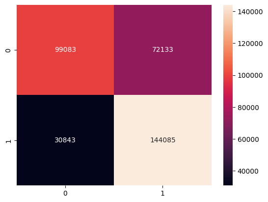

```
Precision score of SGD classifier on train: 0.6663876273020748
Recall score of SGD classifier on train: 0.8236817433458337
```

```python
y_train_predictions = cross_val_predict(sgd_classifier, x_train, y_train, cv=5)
displayResults(y_train, y_train_predictions)
```

We have correctly predicted 144,085 fraudulant cases and missed 30,843, which is okay. The classifier has also mistakenly identified 72,133 unfraudulent trasnactions as fraud

For a basic model this is okay, however it definitely can be improved

Lets see how it performs on the data we set aside from the training set to evaluate how the model performs on unseen data. This will also give us an indication as to whether this model is over- or under-fit

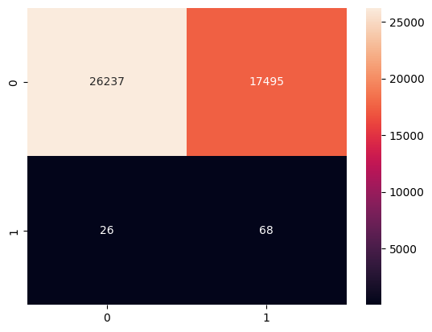

```
Precision score of SGD classifier on train: 0.0038717758925012813
Recall score of SGD classifier on train: 0.723404255319149
```

```python
y_test_predictions = sgd_classifier.predict(x_test)
displayResults(y_test, y_test_predictions)
```

This is similar to above, and seems to be OK for a start. The precision score decreased quite a bit, but the recall score remained pretty similar, so it seems like this is simply due to the imbalanced Classes of the testing set. Regardless, this model does seem to be a bit overfit. We can also compare the ROC-AUC score of the test set.

```python
roc_auc_score(y_test, y_test_predictions)
```

```
0.6616769744536841
```

This score decreased by quite a bit in comparison, indicating that this model does not generalize particularly well and is likely overfit.

### Decision tree classifier

Lets try using a decision tree classifier to see if we can potentially improve on this. A decision tree will provide a nice improvement to the interpretability of our model, although its natural tendency to be overfitted is something we will need to pay attention to in our evaluation.

```python
from sklearn.tree import DecisionTreeClassifier

class_counts = y_train.value_counts()
class_weights = dict(1/class_counts)
tree_classifier = DecisionTreeClassifier(random_state=42, class_weight=class_weights)
tree_classifier.fit(x_train, y_train)
print(cross_val_score(tree_classifier, x_train, y_train, cv = 5, scoring = "roc_auc"))
```

```
[0.98702616 0.98680104 0.9875681  0.98737919 0.98806479]
```

The ROC-AUC scores on the training set have improved quite a bit. We can check the confusion matrix, as well as precision and recall scores on the training data.

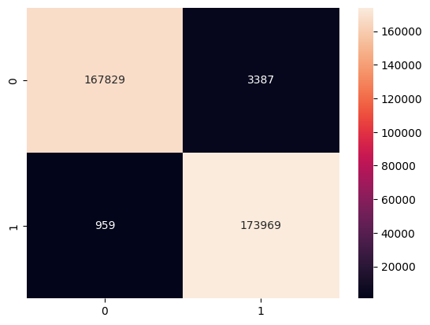

```
Precision score of SGD classifier on train: 0.9809028169331739
Recall score of SGD classifier on train: 0.9945177444434281
```

```python
y_train_predictions = cross_val_predict(tree_classifier, x_train, y_train, cv=5)
displayResults(y_train, y_train_predictions)
```

A much larger fraction of the cases have been correctly identified, which is ideal. However, with accuracy and precision both this high, we may be overfitting the data. Now we will make predictions on the test set and evaluate the performance of this tree classifier.

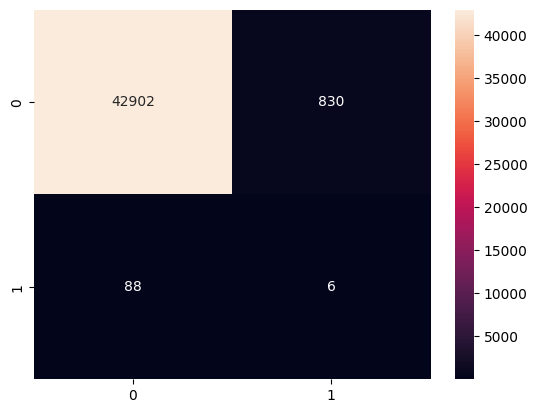

```
Precision score of SGD classifier on train: 0.007177033492822967
Recall score of SGD classifier on train: 0.06382978723404255
```

```python
y_test_predictions = tree_classifier.predict(x_test)

displayResults(y_test, y_test_predictions)
```

This decrease in performance metrics indicates a massive overfitting problem, as the precision and recall scores are significantly lower that they were on the test set. We are misidentifying 830 observations as fraud when they are not, and misidentifying 88 fraud cases as not fraud. This is not what we want to be seeing from this model.

```python
roc_auc_score(y_test, y_test_predictions)
```

```
0.5224252750310887
```

The sharp decrease in ROC-AUC score also backs up this finding.

### Random Forest

We can now try using a Random Forest to see if we can improve our scores from the tree classifier.

```python
y_train_binary = (y_train == 1)
y_test_binary = (y_test == 1)
```

When we fit the RandomForest regressor, there is a tendency for the trained model to massively overfit the data. A solution to this is to utilize the `ccp_alpha` hyperparameter, which provides a form of automated pruning of the trees within the random forest. We can start with a baseline of `ccp_alpha = 0.001` and fine tune this parameter later to see if we can get better results.

```python
from sklearn.ensemble import RandomForestClassifier

forest_classifier = RandomForestClassifier(n_estimators=50, max_depth=10, ccp_alpha=0.001, random_state=42)

forest_classifier.fit(x_train, y_train_binary)
```

```
RandomForestClassifier(ccp_alpha=0.001, max_depth=10, n_estimators=50,
                       random_state=42)
```

Using cross-validation on a random forest can take a significant amount of time, so instead we can move straight into making predictions on the data.

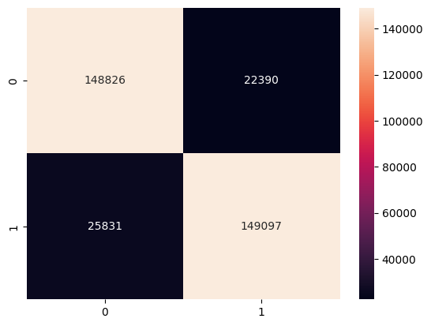

```
Precision score of SGD classifier on train: 0.8694361671730219
Recall score of SGD classifier on train: 0.852333531510107
```

```python
y_train_predictions = forest_classifier.predict_proba(x_train)

positive_class_probabilities = y_train_predictions[:, 1]

displayResults(y_train, positive_class_probabilities)
```

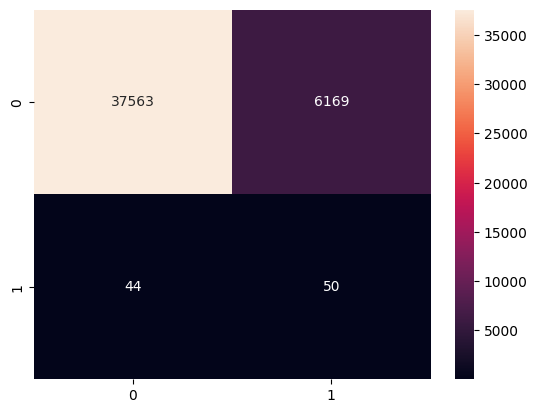

```
Precision score of SGD classifier on train: 0.008039877793857533
Recall score of SGD classifier on train: 0.5319148936170213
```

```python
y_test_predictions = forest_classifier.predict_proba(x_test)

positive_class_probabilities = y_test_predictions[:, 1]

displayResults(y_test, positive_class_probabilities)
```

```python
roc_auc_score(y_test ,positive_class_probabilities)
```

```
0.7779698054494396
```

We can see that we are now misidentifying more cases as fraud, when in fact they are not fraud, which still is not ideal. We are however correctly identifying more fraud cases than we were previously, which, when put into the context of the problem we are trying to solve, may be a good thing. Regardless, we can attempt to create better models using new techniques.

### XGB

Now let us try to use a boosting method to potentially train a better model - here we will use XGB boost.

```python
import xgboost as xgb

xgb_reg = xgb.XGBClassifier(learning_rate = 0.1, max_depth = 37,subsample = 0.88, min_child_weight = 89 ,random_state = 42, gamma = 0.55, colsample_bytree = 0.55)
xgb_reg.fit(x_train, y_train, verbose=False)
```

```
XGBClassifier(base_score=None, booster=None, callbacks=None,
              colsample_bylevel=None, colsample_bynode=None,
              colsample_bytree=0.55, early_stopping_rounds=None,
              enable_categorical=False, eval_metric=None, feature_types=None,
              gamma=0.55, gpu_id=None, grow_policy=None, importance_type=None,
              interaction_constraints=None, learning_rate=0.1, max_bin=None,
              max_cat_threshold=None, max_cat_to_onehot=None,
              max_delta_step=None, max_depth=37, max_leaves=None,
              min_child_weight=89, missing=nan, monotone_constraints=None,
              n_estimators=100, n_jobs=None, num_parallel_tree=None,
              predictor=None, random_state=42, ...)
```

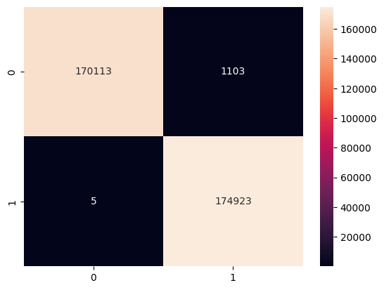

```
Precision score of SGD classifier on train: 0.9937338802222399
Recall score of SGD classifier on train: 0.9999714168114882
```

```python
y_train_predictions = xgb_reg.predict_proba(x_train)
positive_class_probabilities = y_train_predictions[:, 1]
displayResults(y_train, positive_class_probabilities)
```

This returns a similar trend of results to our original tree classifier, which could indicate a bit of overfit, but again we should test how this model performs on the test data before coming to any conclusions.

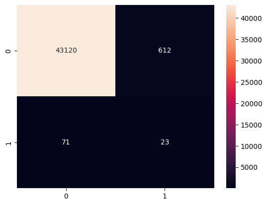

```
Precision score of SGD classifier on train: 0.03622047244094488
Recall score of SGD classifier on train: 0.24468085106382978
```

```python
y_test_predictions = xgb_reg.predict_proba(x_test)
positive_class_probabilities = y_test_predictions[:, 1]
displayResults(y_test, positive_class_probabilities)
```

Our precision and recall scores both decreased quite significantly, indicating an overfitted model. We also seem to be classifying most data as not fraud and are missing a lot of fraud cases, which is not good in terms of the context of the problem

```python
roc_auc_score(y_test ,positive_class_probabilities)
```

```
0.7563111680234154
```

The ROC score is okay, however it is very hard to ovelook the amount of fraud cases we have missed, meaning this model may not be the best to proceed with.

# 6. Fine tune models

Our best model so far was our Random Forest Classifier.

We started with a reasonably good model, but we can now try to fine tune some of the parameters in order to see how good of a classifier we can get. We will first start by performing a grid search on the number of trees within our model, and the maximum depth of each tree.

To try and avoid overfitting, we will be using stratified K fold to keep the feature distributions proportional to the original dataset for each fold.

We will assess each model using the ROC_AUC score.

```python
from sklearn.ensemble import RandomForestClassifier
from sklearn.model_selection import GridSearchCV, StratifiedKFold

random_forrest_classifier = RandomForestClassifier(random_state=42)
cv = StratifiedKFold(n_splits=5)


param_grid = {
    'n_estimators': [75, 50, 25],
    'max_depth': [30, 40, 50],
    'ccp_alpha':[0.001],
}

grid_search_2 = GridSearchCV(estimator=random_forrest_classifier, param_grid=param_grid, cv=cv, scoring='roc_auc', verbose=10)

grid_search_2.fit(x_train, y_train)
```

```
Fitting 5 folds for each of 9 candidates, totalling 45 fits
[CV 1/5; 1/9] START ccp_alpha=0.001, max_depth=30, n_estimators=75..............
[CV 1/5; 1/9] END ccp_alpha=0.001, max_depth=30, n_estimators=75;, score=0.951 total time= 3.6min
[CV 2/5; 1/9] START ccp_alpha=0.001, max_depth=30, n_estimators=75..............
[CV 2/5; 1/9] END ccp_alpha=0.001, max_depth=30, n_estimators=75;, score=0.949 total time= 6.5min
[CV 3/5; 1/9] START ccp_alpha=0.001, max_depth=30, n_estimators=75..............
[CV 3/5; 1/9] END ccp_alpha=0.001, max_depth=30, n_estimators=75;, score=0.949 total time= 5.2min
[CV 4/5; 1/9] START ccp_alpha=0.001, max_depth=30, n_estimators=75..............
[CV 4/5; 1/9] END ccp_alpha=0.001, max_depth=30, n_estimators=75;, score=0.949 total time= 4.6min
[CV 5/5; 1/9] START ccp_alpha=0.001, max_depth=30, n_estimators=75..............
[CV 5/5; 1/9] END ccp_alpha=0.001, max_depth=30, n_estimators=75;, score=0.951 total time= 6.5min
[CV 1/5; 2/9] START ccp_alpha=0.001, max_depth=30, n_estimators=50..............
[CV 1/5; 2/9] END ccp_alpha=0.001, max_depth=30, n_estimators=50;, score=0.949 total time= 4.4min
[CV 2/5; 2/9] START ccp_alpha=0.001, max_depth=30, n_estimators=50..............
[CV 2/5; 2/9] END ccp_alpha=0.001, max_depth=30, n_estimators=50;, score=0.949 total time= 4.5min
[CV 3/5; 2/9] START ccp_alpha=0.001, max_depth=30, n_estimators=50..............
[CV 3/5; 2/9] END ccp_alpha=0.001, max_depth=30, n_estimators=50;, score=0.947 total time= 4.5min
[CV 4/5; 2/9] START ccp_alpha=0.001, max_depth=30, n_estimators=50..............
[CV 4/5; 2/9] END ccp_alpha=0.001, max_depth=30, n_estimators=50;, score=0.948 total time= 3.6min
[CV 5/5; 2/9] START ccp_alpha=0.001, max_depth=30, n_estimators=50..............
[CV 5/5; 2/9] END ccp_alpha=0.001, max_depth=30, n_estimators=50;, score=0.950 total time= 3.2min
[CV 1/5; 3/9] START ccp_alpha=0.001, max_depth=30, n_estimators=25..............
[CV 1/5; 3/9] END ccp_alpha=0.001, max_depth=30, n_estimators=25;, score=0.946 total time= 2.2min
[CV 2/5; 3/9] START ccp_alpha=0.001, max_depth=30, n_estimators=25..............
[CV 2/5; 3/9] END ccp_alpha=0.001, max_depth=30, n_estimators=25;, score=0.946 total time= 2.3min
[CV 3/5; 3/9] START ccp_alpha=0.001, max_depth=30, n_estimators=25..............
[CV 3/5; 3/9] END ccp_alpha=0.001, max_depth=30, n_estimators=25;, score=0.944 total time= 2.2min
[CV 4/5; 3/9] START ccp_alpha=0.001, max_depth=30, n_estimators=25..............
[CV 4/5; 3/9] END ccp_alpha=0.001, max_depth=30, n_estimators=25;, score=0.946 total time= 2.2min
[CV 5/5; 3/9] START ccp_alpha=0.001, max_depth=30, n_estimators=25..............
[CV 5/5; 3/9] END ccp_alpha=0.001, max_depth=30, n_estimators=25;, score=0.948 total time= 2.2min
[CV 1/5; 4/9] START ccp_alpha=0.001, max_depth=40, n_estimators=75..............
[CV 1/5; 4/9] END ccp_alpha=0.001, max_depth=40, n_estimators=75;, score=0.952 total time= 5.8min
[CV 2/5; 4/9] START ccp_alpha=0.001, max_depth=40, n_estimators=75..............
[CV 2/5; 4/9] END ccp_alpha=0.001, max_depth=40, n_estimators=75;, score=0.949 total time= 3.7min
[CV 3/5; 4/9] START ccp_alpha=0.001, max_depth=40, n_estimators=75..............
[CV 3/5; 4/9] END ccp_alpha=0.001, max_depth=40, n_estimators=75;, score=0.952 total time= 3.6min
[CV 4/5; 4/9] START ccp_alpha=0.001, max_depth=40, n_estimators=75..............
[CV 4/5; 4/9] END ccp_alpha=0.001, max_depth=40, n_estimators=75;, score=0.949 total time= 3.6min
[CV 5/5; 4/9] START ccp_alpha=0.001, max_depth=40, n_estimators=75..............
```

[output cut: 36 more lines]

```
[CV 3/5; 8/9] END ccp_alpha=0.001, max_depth=50, n_estimators=50;, score=0.952 total time= 4.6min
[CV 4/5; 8/9] START ccp_alpha=0.001, max_depth=50, n_estimators=50..............
[CV 4/5; 8/9] END ccp_alpha=0.001, max_depth=50, n_estimators=50;, score=0.950 total time= 4.9min
[CV 5/5; 8/9] START ccp_alpha=0.001, max_depth=50, n_estimators=50..............
[CV 5/5; 8/9] END ccp_alpha=0.001, max_depth=50, n_estimators=50;, score=0.950 total time= 4.8min
[CV 1/5; 9/9] START ccp_alpha=0.001, max_depth=50, n_estimators=25..............
[CV 1/5; 9/9] END ccp_alpha=0.001, max_depth=50, n_estimators=25;, score=0.950 total time= 2.4min
[CV 2/5; 9/9] START ccp_alpha=0.001, max_depth=50, n_estimators=25..............
[CV 2/5; 9/9] END ccp_alpha=0.001, max_depth=50, n_estimators=25;, score=0.948 total time= 2.4min
[CV 3/5; 9/9] START ccp_alpha=0.001, max_depth=50, n_estimators=25..............
[CV 3/5; 9/9] END ccp_alpha=0.001, max_depth=50, n_estimators=25;, score=0.949 total time= 2.3min
[CV 4/5; 9/9] START ccp_alpha=0.001, max_depth=50, n_estimators=25..............
[CV 4/5; 9/9] END ccp_alpha=0.001, max_depth=50, n_estimators=25;, score=0.948 total time= 2.3min
[CV 5/5; 9/9] START ccp_alpha=0.001, max_depth=50, n_estimators=25..............
[CV 5/5; 9/9] END ccp_alpha=0.001, max_depth=50, n_estimators=25;, score=0.949 total time= 2.3min
```

```
GridSearchCV(cv=StratifiedKFold(n_splits=5, random_state=None, shuffle=False),
             estimator=RandomForestClassifier(random_state=42),
             param_grid={'ccp_alpha': [0.001], 'max_depth': [30, 40, 50],
                         'n_estimators': [75, 50, 25]},
             scoring='roc_auc', verbose=10)
```

We can print the results

```python
grid_search_results = grid_search_2.cv_results_
for mean_score, params in zip(grid_search_results["mean_test_score"], grid_search_results["params"]):
    print(mean_score, params)
```

```
0.94998701769379 {'ccp_alpha': 0.001, 'max_depth': 30, 'n_estimators': 75}
0.9486627033785193 {'ccp_alpha': 0.001, 'max_depth': 30, 'n_estimators': 50}
0.9461343557020874 {'ccp_alpha': 0.001, 'max_depth': 30, 'n_estimators': 25}
0.9508768231953841 {'ccp_alpha': 0.001, 'max_depth': 40, 'n_estimators': 75}
0.9501747084316585 {'ccp_alpha': 0.001, 'max_depth': 40, 'n_estimators': 50}
0.9479615690425399 {'ccp_alpha': 0.001, 'max_depth': 40, 'n_estimators': 25}
0.9511678320076957 {'ccp_alpha': 0.001, 'max_depth': 50, 'n_estimators': 75}
0.9504231334937305 {'ccp_alpha': 0.001, 'max_depth': 50, 'n_estimators': 50}
0.9484867383891114 {'ccp_alpha': 0.001, 'max_depth': 50, 'n_estimators': 25}
```

*Note we would have also liked to have seen if increasing `n_estimators` improved our score, however the grid searches take a long time and unfortunately we did not have time for this*

We can also test how the `ccp_alpha` hyperparameter will affect our models. To do this, we will use a baseline model of 75 trees with a maximum depth of 30. We can try different levels of `ccp_alpha` and see how they go to preventing overfitting

```python
from sklearn.ensemble import RandomForestClassifier
from sklearn.model_selection import GridSearchCV, StratifiedKFold

random_forrest_classifier = RandomForestClassifier(random_state=42)
cv = StratifiedKFold(n_splits=5)


param_grid = {
    'n_estimators': [75],
    'max_depth': [30],
    'ccp_alpha':[0.0001, 0.0005, 0.001, 0.002, 0.003, 0.004],
}

grid_search_3 = GridSearchCV(estimator=random_forrest_classifier, param_grid=param_grid, cv=cv, scoring='roc_auc', verbose=10)

grid_search_3.fit(x_train, y_train)
```

```
Fitting 5 folds for each of 6 candidates, totalling 30 fits
[CV 1/5; 1/6] START ccp_alpha=0.0001, max_depth=30, n_estimators=75.............
[CV 1/5; 1/6] END ccp_alpha=0.0001, max_depth=30, n_estimators=75;, score=0.999 total time= 7.8min
[CV 2/5; 1/6] START ccp_alpha=0.0001, max_depth=30, n_estimators=75.............
[CV 2/5; 1/6] END ccp_alpha=0.0001, max_depth=30, n_estimators=75;, score=0.999 total time= 8.3min
[CV 3/5; 1/6] START ccp_alpha=0.0001, max_depth=30, n_estimators=75.............
[CV 3/5; 1/6] END ccp_alpha=0.0001, max_depth=30, n_estimators=75;, score=0.999 total time= 7.3min
[CV 4/5; 1/6] START ccp_alpha=0.0001, max_depth=30, n_estimators=75.............
[CV 4/5; 1/6] END ccp_alpha=0.0001, max_depth=30, n_estimators=75;, score=0.999 total time= 3.9min
[CV 5/5; 1/6] START ccp_alpha=0.0001, max_depth=30, n_estimators=75.............
[CV 5/5; 1/6] END ccp_alpha=0.0001, max_depth=30, n_estimators=75;, score=0.999 total time= 4.2min
[CV 1/5; 2/6] START ccp_alpha=0.0005, max_depth=30, n_estimators=75.............
[CV 1/5; 2/6] END ccp_alpha=0.0005, max_depth=30, n_estimators=75;, score=0.982 total time= 4.0min
[CV 2/5; 2/6] START ccp_alpha=0.0005, max_depth=30, n_estimators=75.............
[CV 2/5; 2/6] END ccp_alpha=0.0005, max_depth=30, n_estimators=75;, score=0.982 total time= 3.9min
[CV 3/5; 2/6] START ccp_alpha=0.0005, max_depth=30, n_estimators=75.............
[CV 3/5; 2/6] END ccp_alpha=0.0005, max_depth=30, n_estimators=75;, score=0.982 total time= 3.9min
[CV 4/5; 2/6] START ccp_alpha=0.0005, max_depth=30, n_estimators=75.............
[CV 4/5; 2/6] END ccp_alpha=0.0005, max_depth=30, n_estimators=75;, score=0.981 total time= 3.9min
[CV 5/5; 2/6] START ccp_alpha=0.0005, max_depth=30, n_estimators=75.............
[CV 5/5; 2/6] END ccp_alpha=0.0005, max_depth=30, n_estimators=75;, score=0.982 total time= 3.8min
[CV 1/5; 3/6] START ccp_alpha=0.001, max_depth=30, n_estimators=75..............
[CV 1/5; 3/6] END ccp_alpha=0.001, max_depth=30, n_estimators=75;, score=0.952 total time= 3.8min
[CV 2/5; 3/6] START ccp_alpha=0.001, max_depth=30, n_estimators=75..............
[CV 2/5; 3/6] END ccp_alpha=0.001, max_depth=30, n_estimators=75;, score=0.951 total time= 3.7min
[CV 3/5; 3/6] START ccp_alpha=0.001, max_depth=30, n_estimators=75..............
[CV 3/5; 3/6] END ccp_alpha=0.001, max_depth=30, n_estimators=75;, score=0.951 total time= 3.8min
[CV 4/5; 3/6] START ccp_alpha=0.001, max_depth=30, n_estimators=75..............
[CV 4/5; 3/6] END ccp_alpha=0.001, max_depth=30, n_estimators=75;, score=0.949 total time= 3.7min
[CV 5/5; 3/6] START ccp_alpha=0.001, max_depth=30, n_estimators=75..............
[CV 5/5; 3/6] END ccp_alpha=0.001, max_depth=30, n_estimators=75;, score=0.952 total time= 4.8min
[CV 1/5; 4/6] START ccp_alpha=0.002, max_depth=30, n_estimators=75..............
[CV 1/5; 4/6] END ccp_alpha=0.002, max_depth=30, n_estimators=75;, score=0.901 total time= 7.0min
[CV 2/5; 4/6] START ccp_alpha=0.002, max_depth=30, n_estimators=75..............
[CV 2/5; 4/6] END ccp_alpha=0.002, max_depth=30, n_estimators=75;, score=0.901 total time= 4.1min
[CV 3/5; 4/6] START ccp_alpha=0.002, max_depth=30, n_estimators=75..............
[CV 3/5; 4/6] END ccp_alpha=0.002, max_depth=30, n_estimators=75;, score=0.901 total time= 4.0min
[CV 4/5; 4/6] START ccp_alpha=0.002, max_depth=30, n_estimators=75..............
[CV 4/5; 4/6] END ccp_alpha=0.002, max_depth=30, n_estimators=75;, score=0.900 total time= 4.2min
[CV 5/5; 4/6] START ccp_alpha=0.002, max_depth=30, n_estimators=75..............
[CV 5/5; 4/6] END ccp_alpha=0.002, max_depth=30, n_estimators=75;, score=0.900 total time= 4.6min
[CV 1/5; 5/6] START ccp_alpha=0.003, max_depth=30, n_estimators=75..............
[CV 1/5; 5/6] END ccp_alpha=0.003, max_depth=30, n_estimators=75;, score=0.876 total time= 4.1min
[CV 2/5; 5/6] START ccp_alpha=0.003, max_depth=30, n_estimators=75..............
[CV 2/5; 5/6] END ccp_alpha=0.003, max_depth=30, n_estimators=75;, score=0.874 total time= 3.7min
[CV 3/5; 5/6] START ccp_alpha=0.003, max_depth=30, n_estimators=75..............
[CV 3/5; 5/6] END ccp_alpha=0.003, max_depth=30, n_estimators=75;, score=0.874 total time= 3.7min
[CV 4/5; 5/6] START ccp_alpha=0.003, max_depth=30, n_estimators=75..............
[CV 4/5; 5/6] END ccp_alpha=0.003, max_depth=30, n_estimators=75;, score=0.872 total time= 3.7min
[CV 5/5; 5/6] START ccp_alpha=0.003, max_depth=30, n_estimators=75..............
[CV 5/5; 5/6] END ccp_alpha=0.003, max_depth=30, n_estimators=75;, score=0.875 total time= 3.7min
[CV 1/5; 6/6] START ccp_alpha=0.004, max_depth=30, n_estimators=75..............
[CV 1/5; 6/6] END ccp_alpha=0.004, max_depth=30, n_estimators=75;, score=0.862 total time= 3.7min
[CV 2/5; 6/6] START ccp_alpha=0.004, max_depth=30, n_estimators=75..............
[CV 2/5; 6/6] END ccp_alpha=0.004, max_depth=30, n_estimators=75;, score=0.859 total time= 3.7min
[CV 3/5; 6/6] START ccp_alpha=0.004, max_depth=30, n_estimators=75..............
[CV 3/5; 6/6] END ccp_alpha=0.004, max_depth=30, n_estimators=75;, score=0.860 total time= 3.7min
[CV 4/5; 6/6] START ccp_alpha=0.004, max_depth=30, n_estimators=75..............
[CV 4/5; 6/6] END ccp_alpha=0.004, max_depth=30, n_estimators=75;, score=0.860 total time= 3.7min
[CV 5/5; 6/6] START ccp_alpha=0.004, max_depth=30, n_estimators=75..............
[CV 5/5; 6/6] END ccp_alpha=0.004, max_depth=30, n_estimators=75;, score=0.861 total time= 3.7min
```

```
GridSearchCV(cv=StratifiedKFold(n_splits=5, random_state=None, shuffle=False),
             estimator=RandomForestClassifier(random_state=42),
             param_grid={'ccp_alpha': [0.0001, 0.0005, 0.001, 0.002, 0.003,
                                       0.004],
                         'max_depth': [30], 'n_estimators': [75]},
             scoring='roc_auc', verbose=10)
```

```python
grid_search_results = grid_search_3.cv_results_
for mean_score, params in zip(grid_search_results["mean_test_score"], grid_search_results["params"]):
    print(mean_score, params)
```

```
0.9990493717503206 {'ccp_alpha': 0.0001, 'max_depth': 30, 'n_estimators': 75}
0.9817601909306841 {'ccp_alpha': 0.0005, 'max_depth': 30, 'n_estimators': 75}
0.9508685086676871 {'ccp_alpha': 0.001, 'max_depth': 30, 'n_estimators': 75}
0.9006758344032185 {'ccp_alpha': 0.002, 'max_depth': 30, 'n_estimators': 75}
0.874085084934911 {'ccp_alpha': 0.003, 'max_depth': 30, 'n_estimators': 75}
0.8603964963237326 {'ccp_alpha': 0.004, 'max_depth': 30, 'n_estimators': 75}
```

We can see that a lower `ccp_alpha` score mean better perfomance on the train test, however this is probably because of overfitting. So lets run train each of these models and evaluate on the test set to check for overfitting

```python
for i, params in enumerate(grid_search_3.cv_results_['params']):
    random_forrest_classifier = RandomForestClassifier(**params, random_state=42)
    random_forrest_classifier.fit(x_train, y_train)
    y_pred = random_forrest_classifier.predict_proba(x_test)

    positive_class_probabilities = y_pred[:, 1]
    score = roc_auc_score(y_test ,positive_class_probabilities)
    print(f"Model {i}:\nParameters = {params}\nROC AUC Score = {score:.3f}\n")
```

```
Model 0:
Parameters = {'ccp_alpha': 0.0001, 'max_depth': 30, 'n_estimators': 75}
ROC AUC Score = 0.772

Model 1:
Parameters = {'ccp_alpha': 0.0005, 'max_depth': 30, 'n_estimators': 75}
ROC AUC Score = 0.781

Model 2:
Parameters = {'ccp_alpha': 0.001, 'max_depth': 30, 'n_estimators': 75}
ROC AUC Score = 0.783

Model 3:
Parameters = {'ccp_alpha': 0.002, 'max_depth': 30, 'n_estimators': 75}
ROC AUC Score = 0.785

Model 4:
Parameters = {'ccp_alpha': 0.003, 'max_depth': 30, 'n_estimators': 75}
ROC AUC Score = 0.784

Model 5:
Parameters = {'ccp_alpha': 0.004, 'max_depth': 30, 'n_estimators': 75}
ROC AUC Score = 0.782
```

We can see that a `ccp_alpha` of 0.002 is ideal

## Final model

Now lets build a final model with our optimal parameters

```python
from sklearn.ensemble import RandomForestClassifier

final_model = RandomForestClassifier(ccp_alpha=0.002, max_depth=40, n_estimators=75, random_state=42)
final_model.fit(x_train, y_train)
y_preddictions = final_model.predict_proba(x_test)

positive_class_probabilities = y_preddictions[:, 1]
score = roc_auc_score(y_test ,positive_class_probabilities)
score
```

```
0.7814318985464658
```

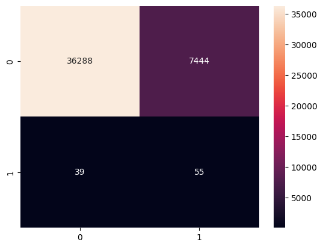

```
Precision score of Tree Classifier test: 0.0073343112414988665
Recall score of Tree Classifier test: 0.5851063829787234
```

```python
labels = np.where(positive_class_probabilities >= 0.5, 1, 0)

matrix = confusion_matrix(y_test, labels)

sns.heatmap(matrix, annot=True, fmt='d')
matplotlib.pyplot.show()

print(f"Precision score of Tree Classifier test: {precision_score(y_test, labels)}")
print(f"Recall score of Tree Classifier test: {recall_score(y_test, labels)}")
```

To evaluate our final model it would be nice to see which features are most important

To do this we can use the built in `model.feature_importances_` function, which calculates the mean reduction in impurity for each feature across all trees in the forest. This will give us a better indication as to which features contain the most explanatory power and tend to be towards the top (stump) of each tree.

```python
importances = final_model.feature_importances_

selected_cols = train.iloc[:, 1:-1]

selected_cols = train.copy().iloc[:, 1:-1].columns

indices = np.argsort(importances)[::-1]

for feature in range(x_train.shape[1]):
    print((f"{feature+1}, {selected_cols[indices[feature]]}: {importances[indices[feature]]}"))
```

```
1, V3: 0.12819438425161667
2, V18: 0.10097714187859114
3, V4: 0.09095881634013189
4, V14: 0.07493421292861056
5, V2: 0.07382335058599833
6, V10: 0.06314734328384368
7, V26: 0.05837022856704846
8, V8: 0.0547766478845607
9, V17: 0.05382886418453079
10, V9: 0.04597938177922059
11, V1: 0.03345364975906513
12, V21: 0.030485229260666404
13, V7: 0.030161481349422422
14, V20: 0.022186822879064493
15, Time: 0.01590959280964325
16, V16: 0.015539195278844594
17, V12: 0.014974024558305444
18, V22: 0.0128533704979497
19, V19: 0.011686379490881688
20, V24: 0.011101810229059204
21, V11: 0.009028216869419368
22, Amount: 0.008936897541962315
23, V13: 0.00680288976186108
24, V6: 0.0066769207051118095
25, V27: 0.006044628142434381
26, V5: 0.005402882775801641
27, V28: 0.004353652658982057
28, V15: 0.004045685891193847
29, V25: 0.0031983115786985154
30, V23: 0.0021679862774798514
```

The ordering of the feature importances seems to be somewhat similar to the order of feature correlation to `Class`, although the difference in rank order could be explained by other factors, such as correlation with other features in the set.

# Conclusion